# Gaussian Mixture Models

```
 ██████╗ ███╗   ███╗███╗   ███╗
██╔════╝ ████╗ ████║████╗ ████║
██║  ███╗██╔████╔██║██╔████╔██║
██║   ██║██║╚██╔╝██║██║╚██╔╝██║
╚██████╔╝██║ ╚═╝ ██║██║ ╚═╝ ██║
 ╚═════╝ ╚═╝     ╚═╝╚═╝     ╚═╝
```

## Table of Contents

- Model Description
- Data set exploration
- Evaluating the optimum number of clusters
- Cluster analysis

## Model Description

A method used for clustering. It assumes that data comes from a distribution that is a combination of several Gaussian distributions.

### Soft Clustering

The clusters in the GMM overlap with each other. The GMM provides what is called a “soft” or probabilistic clustering. Each point does not strictly belong to a single cluster,but instead has a degree or probability of membership in each cluster. In this particular clustering, we can think that a point is more likely to have come from some clusters than others. However, there still is a possibility, perhaps remote, that the point may have come from any of them.

## Required Packages

```r
library(mclust)
```

## Dataset Preparation

```r
data <- iris
summary(data)
```

```
##   Sepal.Length    Sepal.Width     Petal.Length    Petal.Width
##  Min.   :4.300   Min.   :2.000   Min.   :1.000   Min.   :0.100
##  1st Qu.:5.100   1st Qu.:2.800   1st Qu.:1.600   1st Qu.:0.300
##  Median :5.800   Median :3.000   Median :4.350   Median :1.300
##  Mean   :5.843   Mean   :3.057   Mean   :3.758   Mean   :1.199
##  3rd Qu.:6.400   3rd Qu.:3.300   3rd Qu.:5.100   3rd Qu.:1.800
##  Max.   :7.900   Max.   :4.400   Max.   :6.900   Max.   :2.500
##        Species
##  setosa    :50
##  versicolor:50
##  virginica :50
##
##
##
```

### Normilize the data

```r
scaled_data <- scale(data[,c(-5)])
```

## GMM Aplication

```r
# List of clusters to be analysed
test_clusters <- 1:10

# Training the model
model <- Mclust(scaled_data, G=test_clusters)
```

## BIC and AIC metrics

How to select K?

- If we choose K to maximize likelihood, when K increases the value of the maximum likelihood cannot decrease. Thus more complex models will always improve likelihood.
- It is necessary to penalize the complexity of the model. We need a balance between how well the model fits and the data and the simplicity of the model

This is where we choose K based on the score returned either by Akaike information criterion (AIC) or Bayesian information criterion (BIC)

When comparing models fitted by maximum likelihood to the same data, the smaller the AIC or BIC, the better the fit.

```r
AICscores <- c()
BICscores <- c()
for (k in test_clusters) {
  kmodel <- Mclust(scaled_data, G=k)
  AICscores <- append(AICscores, AIC(kmodel, k=2))
  BICscores <- append(BICscores, BIC(kmodel))
}
```

Then we plot the result that each algorithm gave us

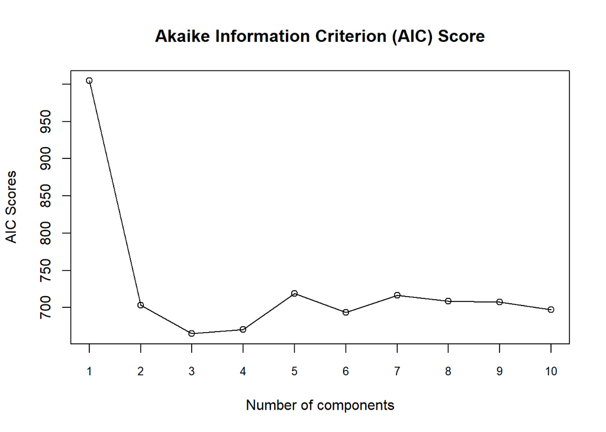

```r
## AIC adn BIC scores comparission
plot(1:length(AICscores), AICscores,
     type = "o",
     main= "Akaike Information Criterion (AIC) Score",
     xlab = "Number of components",
     ylab = "AIC Scores",
     xaxt='n')
axis(side=1, at=1:length(AICscores), labels=1:length(AICscores),cex.axis=0.8)
```

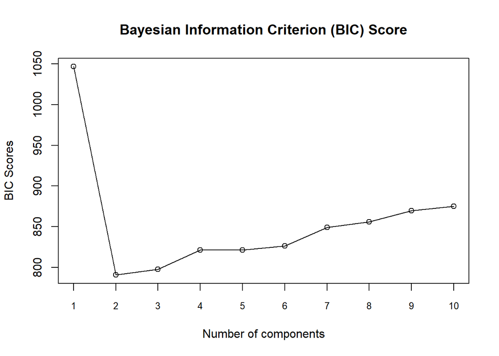

```r
plot(1:length(BICscores), BICscores,
     type = "o",
     main= "Bayesian Information Criterion (BIC) Score",
     xlab = "Number of components",
     ylab = "BIC Scores",
     xaxt='n')
axis(side=1, at=1:length(BICscores), labels=1:length(BICscores),cex.axis=0.8)
```

Mclust function also returns whish form of the clsuter better fit the gaussian density of the data, not only returning his own BIC score results but also the better fitted form.

Here is an image for reference

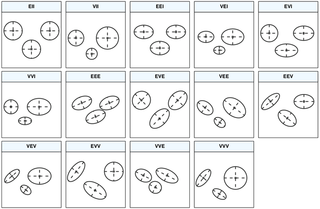

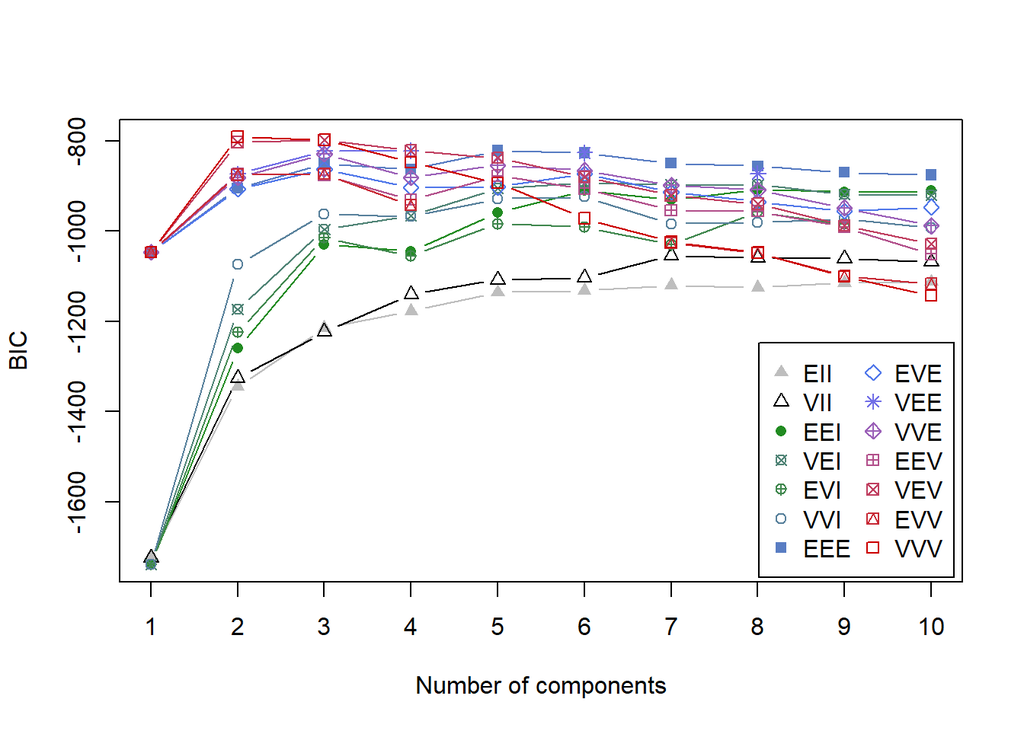

```r
plot(model$BIC)
```

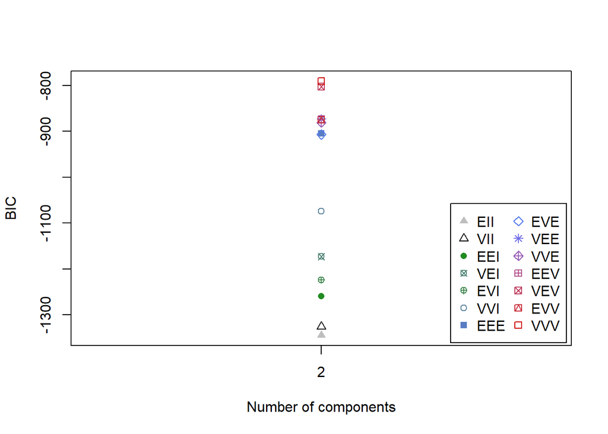

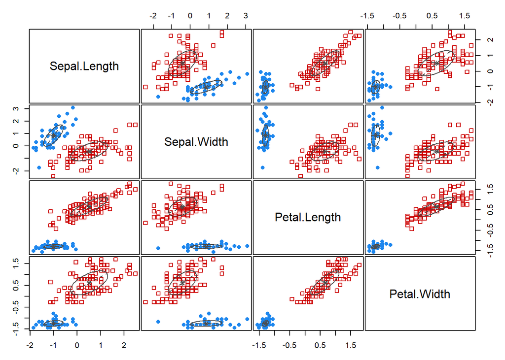

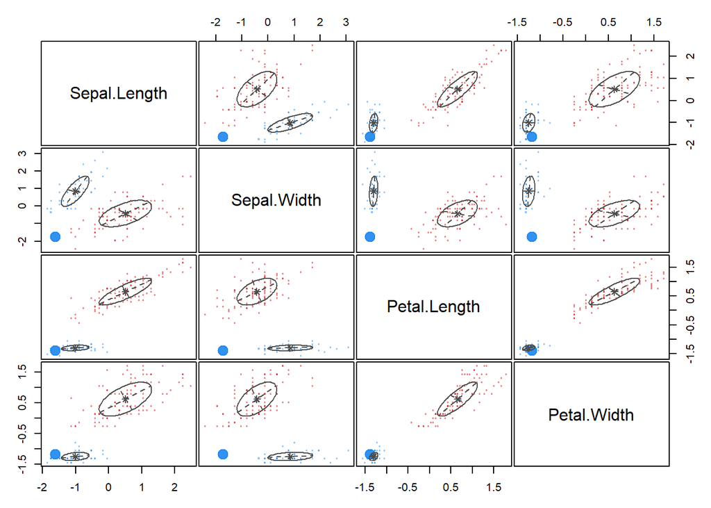

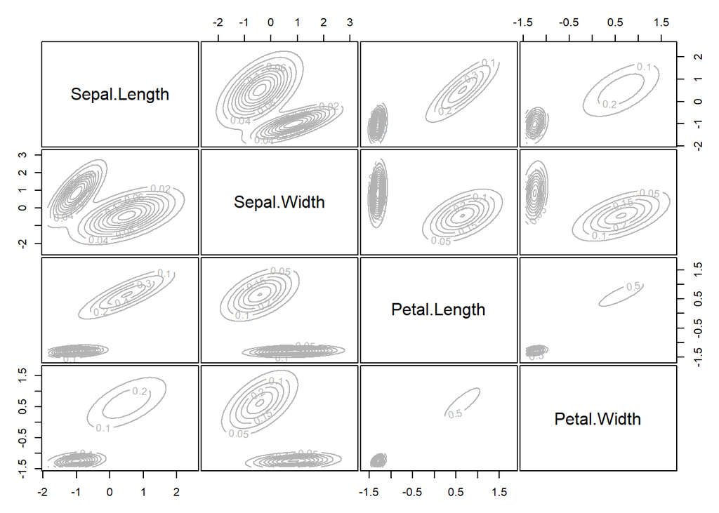

```r
opt_model <- Mclust(scaled_data, G=2)
plot(opt_model)
```

Option 2 gives the actual cluster formed

Options 3 gives rows that the algorithm couldn’t associate with either cluster

Option 4 gives the density form ?? of each clsuter